# Lab-5.2: Variational Convolutional Auto-Encoder

- In this lab we will be working with MNIST, so that the code will run quickly on our laptops.
- However, the concepts can be easily generalized and applied to any data-set.

**Submission:**

- You need to upload ONE document to Canvas when you are done
  - (1) A PDF (or HTML) of the completed form of this notebook
- The final uploaded version should NOT have any code-errors present
- All outputs must be visible in the uploaded version, including code-cell outputs, images, graphs, etc

**Source**: Modified from https://keras.io/examples/generative/vae/

Author: fchollet

### Import

```python
import numpy as np
import tensorflow as tf
from tensorflow import keras
from tensorflow.keras import layers
import matplotlib.pyplot as plt
import pandas as pd
```

### Import data

```
(70000, 28, 28)
(70000, 28, 28, 1)
(28, 28, 1)
(28, 28)
```

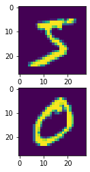

```python
# IMPORT IMAGE (DONT NEED LABELS SINCE IT IS UN-SUPERVISED)
(x_train, _), (x_test, _) = keras.datasets.mnist.load_data()

# JOIN TRAINING AND TEST (THERE IS NO GROUND TRUTH SO DONT NEED TO VALIDATE)
X = np.concatenate([x_train, x_test], axis=0)
print(X.shape)

# NORMALIZE AND RESHAPE SO GRAYSCALE NUMBER IS IN ITS OWN "COLOR CHANNEL"
X = np.expand_dims(X, -1).astype("float32")/255
print(X.shape)

# INSPECT
print(X[0].shape)
print(X[0,:,:,0].shape)

# PLOT DIGITS
f, ax = plt.subplots(2,1)
ax[0].imshow(X[0])
ax[1].imshow(X[1])
plt.show()
```

### Model

The following code cells construct the Convolutional VAE model

#### 5.2.1 Sampling layer

The following code is intentionally un-commented.

(1) In your own words, carefully add code-comments to the following cell to describe what exactly the code is doing.

(2) You don't need to go deep into details, however, your comments should make it clear to an outsider what is occurring in the code block

```python
class Sampling(layers.Layer):
    """Uses (z_mean, z_log_var) to sample z, the vector encoding a digit."""

    #implement custom layers by writng a call funtion
    def call(self, inputs):
        z_mean, z_log_var = inputs #encodes the input into a mean and variance parameter
        batch = tf.shape(z_mean)[0]
        dim = tf.shape(z_mean)[1]
        epsilon = tf.keras.backend.random_normal(shape=(batch, dim)) # epsilon is a random tensor of small values
        return z_mean + tf.exp(0.5 * z_log_var) * epsilon #draws a latent point using a small random epsilon
```

#### 5.2.2 Encoder

The following code is intentionally un-commented.

(1) In your own words, carefully add code-comments to the following cell to describe what exactly the code is doing.

(2) You don't need to go deep into details, however, your comments should make it clear to an outsider what is occurring in the code block

```python
latent_dim = 2 #2D plane

# mapping images to the parameters of a probability distribution over the latent space
encoder_inputs = keras.Input(shape=(28, 28, 1))
x = layers.Conv2D(32, 3, activation="relu", strides=2, padding="same")(encoder_inputs)
x = layers.Conv2D(64, 3, activation="relu", strides=2, padding="same")(x)
x = layers.Flatten()(x)
x = layers.Dense(16, activation="relu")(x)

# the input image ended up being encoded into 2 parameters below
z_mean = layers.Dense(latent_dim, name="z_mean")(x)
z_log_var = layers.Dense(latent_dim, name="z_log_var")(x)

#the parameters of the statistical distribution assumed to generate a latent space point z
z = Sampling()([z_mean, z_log_var])
encoder = keras.Model(encoder_inputs, [z_mean, z_log_var, z], name="encoder")
encoder.summary()
```

```
2022-11-28 19:18:17.461432: I tensorflow/core/platform/cpu_feature_guard.cc:151] This TensorFlow binary is optimized with oneAPI Deep Neural Network Library (oneDNN) to use the following CPU instructions in performance-critical operations:  SSE4.1 SSE4.2
To enable them in other operations, rebuild TensorFlow with the appropriate compiler flags.
```

```
Model: "encoder"
__________________________________________________________________________________________________
 Layer (type)                   Output Shape         Param #     Connected to
==================================================================================================
 input_1 (InputLayer)           [(None, 28, 28, 1)]  0           []

 conv2d (Conv2D)                (None, 14, 14, 32)   320         ['input_1[0][0]']

 conv2d_1 (Conv2D)              (None, 7, 7, 64)     18496       ['conv2d[0][0]']

 flatten (Flatten)              (None, 3136)         0           ['conv2d_1[0][0]']

 dense (Dense)                  (None, 16)           50192       ['flatten[0][0]']

 z_mean (Dense)                 (None, 2)            34          ['dense[0][0]']

 z_log_var (Dense)              (None, 2)            34          ['dense[0][0]']

 sampling (Sampling)            (None, 2)            0           ['z_mean[0][0]',
                                                                  'z_log_var[0][0]']

==================================================================================================
Total params: 69,076
Trainable params: 69,076
Non-trainable params: 0
__________________________________________________________________________________________________
```

#### 5.2.3 Decoder

The following code is intentionally un-commented.

(1) In your own words, carefully add code-comments to the following cell to describe what exactly the code is doing.

(2) You don't need to go deep into details, however, your comments should make it clear to an outsider what is occurring in the code block

```python
latent_inputs = keras.Input(shape=(latent_dim,))
x = layers.Dense(7 * 7 * 64, activation="relu")(latent_inputs)

#reshape x into a feature map to fit in the following layers
x = layers.Reshape((7, 7, 64))(x)

# Uses a Conv2DTranspose layer to decode inputs into a feature map the same size as the original image input
x = layers.Conv2DTranspose(64, 3, activation="relu", strides=2, padding="same")(x)
x = layers.Conv2DTranspose(32, 3, activation="relu", strides=2, padding="same")(x)
decoder_outputs = layers.Conv2DTranspose(1, 3, activation="sigmoid", padding="same")(x)
decoder = keras.Model(latent_inputs, decoder_outputs, name="decoder")
decoder.summary()
```

```
Model: "decoder"
_________________________________________________________________
 Layer (type)                Output Shape              Param #
=================================================================
 input_2 (InputLayer)        [(None, 2)]               0

 dense_1 (Dense)             (None, 3136)              9408

 reshape (Reshape)           (None, 7, 7, 64)          0

 conv2d_transpose (Conv2DTra  (None, 14, 14, 64)       36928
 nspose)

 conv2d_transpose_1 (Conv2DT  (None, 28, 28, 32)       18464
 ranspose)

 conv2d_transpose_2 (Conv2DT  (None, 28, 28, 1)        289
 ranspose)

=================================================================
Total params: 65,089
Trainable params: 65,089
Non-trainable params: 0
_________________________________________________________________
```

#### 5.2.4 VAE: Putting it all together

The following code is intentionally un-commented.

(1) In your own words, carefully add code-comments to the following cell to describe what exactly the code is doing.

(2) You don't need to go deep into details, however, your comments should make it clear to an outsider what is occurring in the code block

```python
class VAE(keras.Model):
    def __init__(self, encoder, decoder, **kwargs):
        super(VAE, self).__init__(**kwargs)
        self.encoder = encoder
        self.decoder = decoder
        self.total_loss_tracker = keras.metrics.Mean(name="total_loss")
        self.reconstruction_loss_tracker = keras.metrics.Mean(
            name="reconstruction_loss"
        )
        self.kl_loss_tracker = keras.metrics.Mean(name="kl_loss")

    @property
    def metrics(self):
        return [
            self.total_loss_tracker,
            self.reconstruction_loss_tracker,
            self.kl_loss_tracker,
        ]

    def train_step(self, data):
        with tf.GradientTape() as tape:
            z_mean, z_log_var, z = self.encoder(data)
            reconstruction = self.decoder(z)

            #set up the loss method to create arbitrary loss
            reconstruction_loss = tf.reduce_mean(
                tf.reduce_sum(
                    keras.losses.binary_crossentropy(data, reconstruction), axis=(1, 2)
                )
            )
            kl_loss = -0.5 * (1 + z_log_var - tf.square(z_mean) - tf.exp(z_log_var))
            kl_loss = tf.reduce_mean(tf.reduce_sum(kl_loss, axis=1))
            total_loss = reconstruction_loss + kl_loss
        grads = tape.gradient(total_loss, self.trainable_weights)
        self.optimizer.apply_gradients(zip(grads, self.trainable_weights))
        self.total_loss_tracker.update_state(total_loss)
        self.reconstruction_loss_tracker.update_state(reconstruction_loss)
        self.kl_loss_tracker.update_state(kl_loss)
        return {
            "loss": self.total_loss_tracker.result(),
            "reconstruction_loss": self.reconstruction_loss_tracker.result(),
            "kl_loss": self.kl_loss_tracker.result(),
        }
```

### Train

```python
#initiate and train the model
vae = VAE(encoder, decoder)
vae.compile(optimizer=keras.optimizers.Adam())
vae.fit(X, epochs=30, batch_size=128)
```

```
<keras.callbacks.History at 0x7f97d9b90c40>
```

### 5.2.5 Visualize results

The following code is intentionally un-commented.

(1) In your own words, carefully add code-comments to the following cell to describe what exactly the code is doing.

(2) You don't need to go deep into details, however, your comments should make it clear to an outsider what is occurring in the code block

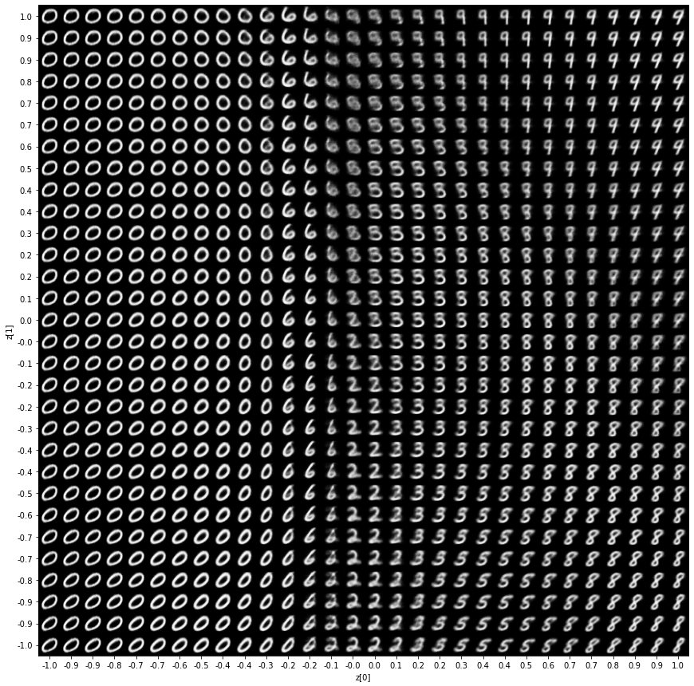

```python
def plot_latent_space(vae, n=30, figsize=15): #display a grid of 30*30 digits
    digit_size = 28
    scale = 1.0
    figure = np.zeros((digit_size * n, digit_size * n))
    grid_x = np.linspace(-scale, scale, n)
    grid_y = np.linspace(-scale, scale, n)[::-1]
    for i, yi in enumerate(grid_y):
        for j, xi in enumerate(grid_x):
            z_sample = np.array([[xi, yi]])
            x_decoded = vae.decoder.predict(z_sample) #decode into digit images
            digit = x_decoded[0].reshape(digit_size, digit_size) #reshape the first digit in the batch from 28 × 28 × 1 to 28 × 28
            figure[
                i * digit_size : (i + 1) * digit_size,
                j * digit_size : (j + 1) * digit_size,
            ] = digit
    plt.figure(figsize=(figsize, figsize))
    start_range = digit_size // 2
    end_range = n * digit_size + start_range
    pixel_range = np.arange(start_range, end_range, digit_size)
    sample_range_x = np.round(grid_x, 1)
    sample_range_y = np.round(grid_y, 1)
    plt.xticks(pixel_range, sample_range_x)
    plt.yticks(pixel_range, sample_range_y)
    plt.xlabel("z[0]")
    plt.ylabel("z[1]")
    plt.imshow(figure, cmap="Greys_r")
    plt.show()

#grid of digits decoded from the latent space
plot_latent_space(vae)
```

## Visualize latent space

Display how the latent space clusters different digit classes

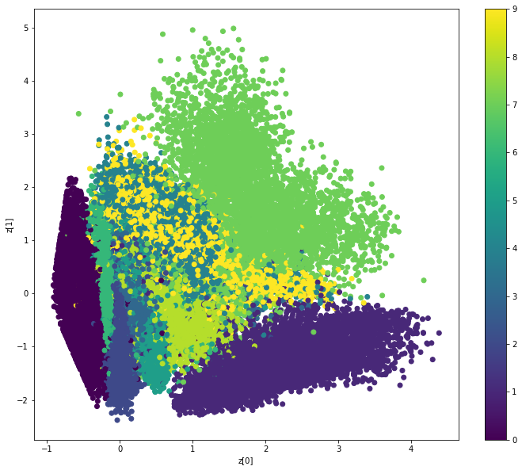

```python
def plot_label_clusters(vae, data, labels):
    # display a 2D plot of the digit classes in the latent space
    z_mean, _, _ = vae.encoder.predict(data)
    plt.figure(figsize=(12, 10))
    plt.scatter(z_mean[:, 0], z_mean[:, 1], c=labels)
    plt.colorbar()
    plt.xlabel("z[0]")
    plt.ylabel("z[1]")
    plt.show()


(x_train, y_train), _ = keras.datasets.mnist.load_data()
x_train = np.expand_dims(x_train, -1).astype("float32") / 255

plot_label_clusters(vae, x_train, y_train)
```